# chapter-4-battle-of-the-tech-giants-for-talent

Xiaotian Sun

15/02/2020

## 4. Battle of the Tech Giants for Talent

##### 4.1 Amazon vs. Google (video)

**text mining workflow**

- 1. Problem definition & specific goals
- 2. Identify text to be collected
- 3. Text organization
- 4. Feature extraction
- 5. Analysis
- 6. Reach an insight

##### 4.2 Organizing a text mining project

##### 4.3 Step 1: Problem definition

- Does Amazon or Google have a better perceived pay according to online reviews?
- Does Amazon or Google have a better work-life balance according to current employees?

##### 4.4 Step 2: Identifying the text sources

Employee reviews can come from various sources. If your human resources department had the resources, you could have a third party administer focus groups to interview employees both internally and from your competitor.

Forbes and others publish articles about the “best places to work”, which may mention Amazon and Google. Another source of information might be anonymous online reviews from websites like Indeed, Glassdoor or CareerBliss.

Here, we’ll focus on a collection of anonymous online reviews.

*Instruction:*

- View the structure of `amzn` with `str()` to get its dimensions and a preview of the data.
- Create `amzn_pros` from the positive reviews column `amzn$pros`.
- Create `amzn_cons` from the negative reviews column `amzn$cons`.
- Print the structure of `goog` with `str()` to get its dimensions and a preview of the data.
- Create `goog_pros` from the positive reviews column `goog$pros`.
- Create `goog_cons` from the negative reviews column `goog$cons`.

```r
# Print the structure of amzn
str(amzn)
```

```
## 'data.frame':    500 obs. of  4 variables:
##  $ pg_num: int  50 50 50 50 50 50 50 50 50 50 ...
##  $ url   : Factor w/ 58 levels "https://www.glassdoor.com/Reviews/Amazon-com-Reviews-E6036_P10.htm",..: 44 44 44 44 44 44 44 44 44 44 ...
##  $ pros  : Factor w/ 496 levels "- Learn a lot, haven't been bored yet.",..: 492 56 152 349 359 367 183 417 210 352 ...
##  $ cons  : Factor w/ 495 levels "*Depending on your manager, might work long hours",..: 156 276 246 89 288 187 374 212 112 160 ...
```

```r
# Create amzn_pros
amzn_pros <- amzn$pros

# Create amzn_cons
amzn_cons <- amzn$cons

# Print the structure of goog
str(goog)
```

```
## 'data.frame':    501 obs. of  4 variables:
##  $ pg_num: int  1 1 1 1 1 1 1 1 1 1 ...
##  $ url   : Factor w/ 50 levels "https://www.glassdoor.com/Reviews/Google-Reviews-E9079_P1.htm",..: 1 1 1 1 1 1 1 1 1 1 ...
##  $ pros  : Factor w/ 492 levels "- Access to a vast wealth of technical resources and people",..: 21 27 488 12 410 233 413 376 314 384 ...
##  $ cons  : Factor w/ 491 levels "- Bureaucracy, politics, legal issues, and privacy handling take up more and more time over the years and slow "| __truncated__,..: 18 26 176 6 296 62 453 447 186 113 ...
```

```r
# Create goog_pros
goog_pros <- goog$pros

# Create goog_cons
goog_cons <- goog$cons
```

##### 4.5 Step 3:Text organization (video)

- text oragnization with qdap
- text organization with tm
- cleaning your corpora

##### 4.6 Text organization

*Instruction 1:*

- Apply `qdap_clean()` to `amzn_pros`, assigning to `qdap_cleaned_amzn_pros`.
- Create a vector source (`VectorSource()`) from `qdap_cleaned_amzn_pros`, then turn it into a volatile corpus (`VCorpus()`), assigning to `amzn_p_corp`.
- Create `amzn_pros_corp` by applying `tm_clean()` to `amzn_p_corp`.

```r
# qdap_clean the text
qdap_cleaned_amzn_pros <- qdap_clean(amzn_pros)

# Source and create the corpus
amzn_p_corp <- VCorpus(VectorSource(qdap_cleaned_amzn_pros))

# tm_clean the corpus
amzn_pros_corp <- tm_clean(amzn_p_corp)
```

*Instruction 2:* - Apply `qdap_clean()` to `amzn_cons`, assigning to `qdap_cleaned_amzn_cons`.

- Create a vector source from `qdap_cleaned_amzn_cons`, then turn it into a volatile corpus, assigning to `amzn_c_corp`.
- Create `amzn_cons_corp` by applying `tm_clean()` to `amzn_c_corp`.

```r
# qdap_clean the text
qdap_cleaned_amzn_cons <- qdap_clean(amzn_cons)

# Source and create the corpus
amzn_c_corp <- VCorpus(VectorSource(qdap_cleaned_amzn_cons))

# tm_clean the corpus
amzn_cons_corp <- tm_clean(amzn_c_corp)
```

##### 4.7 Working with Google reviews

Now that the Amazon reviews have been cleaned, the same must be done for the Google reviews. `qdap_clean()` and `tm_clean()` are available in your workspace to help you clean goog_pros and goog_cons.

*Instruction 1:*

- Apply `qdap_clean()` to `goog_pros`, assigning to `qdap_cleaned_goog_pros`.
- Create a vector source (`VectorSource()`) from `qdap_cleaned_goog_pros`, then turn it into a volatile corpus (`VCorpus()`), assigning to `goog_p_corp`.
- Create `goog_pros_corp` by applying `tm_clean()` to `goog_p_corp`.

```r
# qdap_clean the text
qdap_cleaned_goog_pros <- qdap_clean(goog_pros)

# Source and create the corpus
goog_p_corp <- VCorpus(VectorSource(qdap_cleaned_goog_pros))

# tm_clean the corpus
goog_pros_corp <- tm_clean(goog_p_corp)
```

*Instruction 2:*

- Apply `qdap_clean()` to `goog_cons`, assigning to `qdap_cleaned_goog_cons`.
- Create a vector source from `qdap_cleaned_goog_cons`, then turn it into a volatile corpus, assigning to `goog_c_corp`.
- Create `goog_cons_corp` by applying `tm_clean()` to `goog_c_corp`.

```r
# qdap clean the text
qdap_cleaned_goog_cons <- qdap_clean(goog_cons)

# Source and create the corpus
goog_c_corp <- VCorpus(VectorSource(qdap_cleaned_goog_cons))

# tm clean the corpus
goog_cons_corp <- tm_clean(goog_c_corp)
```

##### 4.8 Steps 4 & 5: Feature extraction & analysis

##### 4.9 Feature extraction & analysis: amzn_pros

`amzn_pros_corp`, `amzn_cons_corp`, `goog_pros_corp` and `goog_cons_corp` have all been preprocessed, so now you can extract the features you want to examine. Since you are using the bag of words approach, you decide to create a bigram `TermDocumentMatrix` for Amazon’s positive reviews corpus, `amzn_pros_corp`. From this, you can quickly create a `wordcloud()` to understand what phrases people positively associate with working at Amazon.

The function below uses `RWeka` to tokenize two terms and is used behind the scenes in this exercise.

> tokenizer <- function(x) { NGramTokenizer(x, Weka_control(min = 2, max = 2)) }

*Instruction:*

- Create `amzn_p_tdm` as a `TermDocumentMatrix` from `amzn_pros_corp`. Make sure to add `control = list(tokenize = tokenizer)` so that the terms are bigrams.
- Create `amzn_p_tdm_m` from `amzn_p_tdm` by using the `as.matrix()` function.
- Create `amzn_p_freq` to obtain the term frequencies from `amzn_p_tdm_m`.
- Create a `wordcloud()` using `names(amzn_p_freq)` as the words, `amzn_p_freq` as their frequencies, and `max.words = 25` and `color = "blue"` for aesthetics.

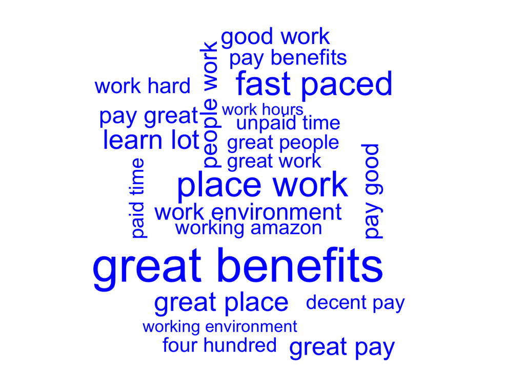

```r
# Create amzn_p_tdm
amzn_p_tdm <- TermDocumentMatrix(
  amzn_pros_corp,
  control = list(tokenize = tokenizer))

# Create amzn_p_tdm_m
amzn_p_tdm_m <- as.matrix(amzn_p_tdm)

# Create amzn_p_freq
amzn_p_freq <- rowSums(amzn_p_tdm_m)

# Plot a wordcloud using amzn_p_freq values
wordcloud(names(amzn_p_freq),
  amzn_p_freq,
  max.words = 25,
  color = "blue")
```

##### 4.10 Feature extraction & analysis: amzn_cons

You now decide to contrast this with the `amzn_cons_corp` corpus in another bigram TDM. Of course, you expect to see some different phrases in your word cloud.

Once again, you will use this custom function to extract your bigram features for the visual:

> tokenizer <- function(x) NGramTokenizer(x, Weka_control(min = 2, max = 2))

*Instruction:*

- Create `amzn_c_tdm` by converting `amzn_cons_corp` into a `TermDocumentMatrix` and incorporating the bigram function `control = list(tokenize = tokenizer)`.
- Create `amzn_c_tdm_m` as a matrix version of `amzn_c_tdm`.
- Create `amzn_c_freq` by using `rowSums()` to get term frequencies from `amzn_c_tdm_m`.
- Create a `wordcloud()` using `names(amzn_c_freq)` and the values `amzn_c_freq`. Use the arguments `max.words = 25` and `color = "red"` as well.

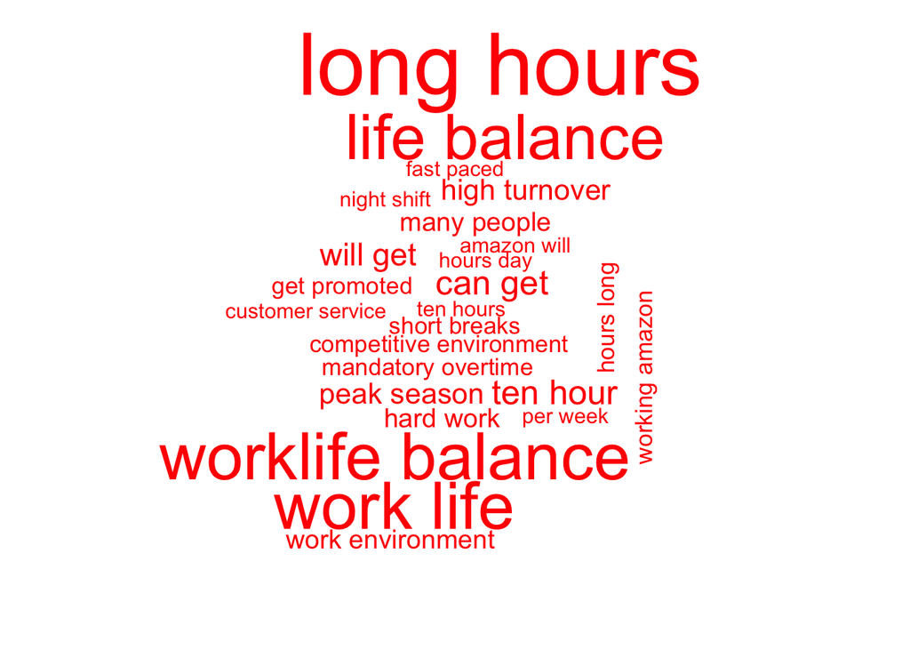

```r
# Create amzn_c_tdm
amzn_c_tdm <- TermDocumentMatrix(
  amzn_cons_corp,
  control = list(tokenize = tokenizer))

# Create amzn_c_tdm_m
amzn_c_tdm_m <- as.matrix(amzn_c_tdm)

# Create amzn_c_freq
amzn_c_freq <- rowSums(amzn_c_tdm_m)

# Plot a wordcloud of negative Amazon bigrams
wordcloud(names(amzn_c_freq), amzn_c_freq,
  max.words = 25, color = "red")
```

##### 4.11 amzn_cons dendrogram

It seems there is a strong indication of long working hours and poor work-life balance in the reviews. As a simple clustering technique, you decide to perform a hierarchical cluster and create a dendrogram to see how connected these phrases are.

*Instruction:*

- Create `amzn_c_tdm` as a `TermDocumentMatrix` using `amzn_cons_corp` with `control = list(tokenize = tokenizer)`.
- Print `amzn_c_tdm` to the console.
- Create `amzn_c_tdm2` by applying the `removeSparseTerms()` function to `amzn_c_tdm` with the sparse argument equal to `.993`.
- Create `hc`, a hierarchical cluster object by nesting the distance matrix `dist(amzn_c_tdm2)` inside the `hclust()` function. Make sure to also pass `method = "complete"` to the `hclust()` function.
- Plot `hc` to view the clustered bigrams and see how the concepts in the Amazon cons section may lead you to a conclusion.

```r
# Create amzn_c_tdm
amzn_c_tdm <- TermDocumentMatrix(
  amzn_cons_corp,
  control = list(tokenize = tokenizer))

# Print amzn_c_tdm to the console
amzn_c_tdm
```

```
## <<TermDocumentMatrix (terms: 4778, documents: 500)>>
## Non-/sparse entries: 5220/2383780
## Sparsity           : 100%
## Maximal term length: 31
## Weighting          : term frequency (tf)
```

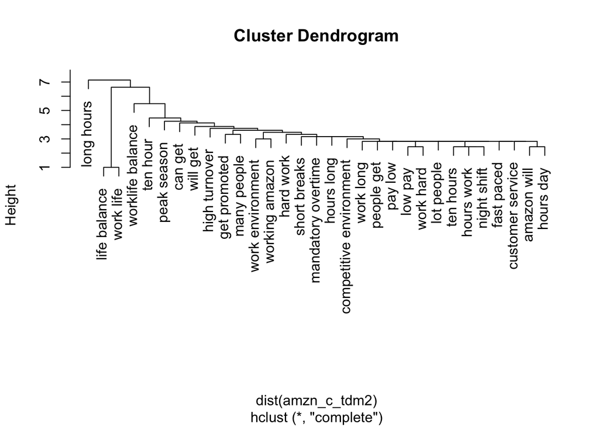

```r
# Create amzn_c_tdm2 by removing sparse terms
amzn_c_tdm2 <- removeSparseTerms(amzn_c_tdm, sparse = .993)

# Create hc as a cluster of distance values
hc <- hclust(
  d = dist(amzn_c_tdm2), method = "complete")

# Produce a plot of hc
plot(hc)
```

##### 4.12 Word association

As expected, you see similar topics throughout the dendrogram. Switching back to positive comments, you decide to examine top phrases that appeared in the word clouds. You hope to find associated terms using the `findAssocs()` function from `tm`. You want to check for something surprising now that you have learned of long hours and a lack of work-life balance.

*Instruction:*

The `amzn_pros_corp` corpus has been cleaned using the custom functions like before.

- Construct a TDM called `amzn_p_tdm` from `amzn_pros_corp` and `control = list(tokenize = tokenizer)`.
- Create `amzn_p_m` by converting `amzn_p_tdm` to a matrix.
- Create `amzn_p_freq` by applying `rowSums()` to `amzn_p_m`.
- Create `term_frequency` using `sort()` on `amzn_p_freq` along with the argument `decreasing = TRUE`.
- Examine the first 5 bigrams using `term_frequency[1:5]`.
- You may be surprised to see “fast paced” as a top term because it could be a negative term related to “long hours”. Look at the terms most associated with “fast paced”. Use `findAssocs()` on `amzn_p_tdm` to examine `"fast paced"` with a `0.2` cutoff.

```r
# Create amzn_p_tdm
amzn_p_tdm <- TermDocumentMatrix(
  amzn_pros_corp,
  control = list(tokenize = tokenizer)
)

# Create amzn_p_m
amzn_p_m <- as.matrix(amzn_p_tdm)

# Create amzn_p_freq
amzn_p_freq <- rowSums(amzn_p_m)

# Create term_frequency
term_frequency <- sort(amzn_p_freq, decreasing = T)

# Print the 5 most common terms
term_frequency[1:5]
```

[output not shown]

```r
# Find associations with fast paced
associations <- findAssocs(amzn_p_tdm, "fast paced", 0.2)
associations
```

```
## $`fast paced`
##        paced environment        environments ever               learn fast
##                     0.49                     0.35                     0.35
##           paced friendly               paced work               able excel
##                     0.35                     0.35                     0.25
##           activity ample              advance one                also well
##                     0.25                     0.25                     0.25
##              amazon fast            amazon noting               amazon one
##                     0.25                     0.25                     0.25
##              amount time        ample opportunity        assistance ninety
##                     0.25                     0.25                     0.25
##       benefits including           break computer            call activity
##                     0.25                     0.25                     0.25
##               can choose            catchy cheers            center things
##                     0.25                     0.25                     0.25
##       challenging expect       cheers opportunity           choose success
##                     0.25                     0.25                     0.25
##   combined encouragement competitive environments            computer room
##                     0.25                     0.25                     0.25
##              cool things          deliver results               dock makes
##                     0.25                     0.25                     0.25
##           driven deliver               easy learn        emphasis shipping
##                     0.25                     0.25                     0.25
## encouragement innovation     environment benefits       environment catchy
##                     0.25                     0.25                     0.25
##       environment center         environment fast         environment help
##                     0.25                     0.25                     0.25
##        environment smart               ever known           ever witnessed
##                     0.25                     0.25                     0.25
##        everchanging fast    everyones preferences            excel advance
##                     0.25                     0.25                     0.25
##       excel everchanging     exciting environment             expect learn
##                     0.25                     0.25                     0.25
##           extremely fast             facility top          fail successful
##                     0.25                     0.25                     0.25
##           fantastic able               fired part             five percent
##                     0.25                     0.25                     0.25
##           freindly place      friendly atmosphere      friendly management
##                     0.25                     0.25                     0.25
##             full medical                get fired             go extremely
```

[output cut: 40 more lines]

```
##                     0.25                     0.25                     0.25
##         technology today         things happening               things lot
##                     0.25                     0.25                     0.25
##                time fast                  time go                 top line
##                     0.25                     0.25                     0.25
##       upfront experience              vision well              volume call
##                     0.25                     0.25                     0.25
##            well rewarded             well tuition       witnessed combined
##                     0.25                     0.25                     0.25
##                 work can                work cool        work environments
##                     0.25                     0.25                     0.25
##                work fast                 work job          workers readily
##                     0.25                     0.25                     0.25
##              yell leader
##                     0.25
```

##### 4.13 Quick review of Google reviews

You decide to create a `comparison.cloud()` of Google’s positive and negative reviews for comparison to Amazon. This will give you a quick understanding of top terms without having to spend as much time as you did examining the Amazon reviews in the previous exercises.

We’ve provided you with a corpus `all_goog_corpus`, which has the 500 positive and 500 negative reviews for Google. Here, you’ll clean the corpus and create a comparison cloud comparing the common words in both pro and con reviews.

*Instruction:*

The `all_goog_corpus` object consisting of Google pro and con reviews is loaded in your workspace.

- Create `all_goog_corp` by cleaning `all_goog_corpus` with the predefined `tm_clean()` function.
- Create `all_tdm` by converting `all_goog_corp` to a term-document matrix.
- Create `all_m` by converting `all_tdm` to a matrix.
- Construct a `comparison.cloud()` from `all_m`. Set `max.words` to `100`. The `colors` argument is specified for you.

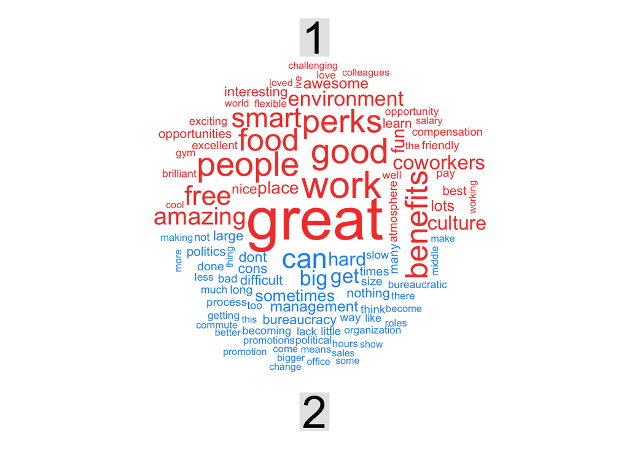

```r
# Create all_goog_corp
all_goog_corp <- tm_clean(all_goog_corpus)

# Create all_tdm
all_tdm <- TermDocumentMatrix(all_goog_corp)

# Create all_m
all_m <- as.matrix(all_tdm)

# Build a comparison cloud
comparison.cloud(all_m,
  colors = c("#F44336", "#2196f3"),
  max.words = 100)
```

##### 4.14 Cage match! Amazon vs. Google pro reviews

In contrast, Google’s positive reviews mention “great food”, “perks”, “smart people”, and “fun culture”, among other things. Google’s negative reviews discuss “politics”, “getting big”, “bureaucracy”, and “middle management”.

You decide to make a pyramid plot lining up positive reviews for Amazon and Google so you can compare the differences between any shared bigrams. We have preloaded a data frame, `all_tdm_df`, consisting of `terms` and corresponding `AmazonPro`, and `GooglePro` bigram frequencies. Using this data frame you will identify the top 5 bigrams that are shared between the two corpora.

*Instruction:*

- Create `common_words` from `all_tdm_df` using `dplyr` functions.
  - `filter()` on the `AmazonPro` column for nonzero values.
  - Likewise filter the `GooglePro` column for nonzero values.
  - Then `mutate()` a new column, `diff` which is the `abs` (absolute) difference between the term frequencies columns.
- Although we could have piped again, create `top5_df` by applying `top_n` to `common_words` to extract the top `5` values in the `diff` column. It will print to your console for review.
- Create a `pyramid.plot` passing in `top5_df$AmazonPro` then `top5_df$GooglePro` and finally add labels with `top5_df$terms`.

```r
# Filter to words in common and create an absolute diff column
common_words <- all_tdm_df %>%
  filter(
    AmazonPro != 0,
    GooglePro != 0
  ) %>%
  mutate(diff = abs(AmazonPro - GooglePro))

# Extract top 5 common bigrams
(top5_df <- top_n(common_words, 5))

# Create the pyramid plot
pyramid.plot(top5_df$AmazonPro, top5_df$GooglePro,
             labels = top5_df$terms, gap = 12,
             top.labels = c("Amzn", "Pro Words", "Goog"),
             main = "Words in Common", unit = NULL)
```

[output not shown]

##### 4.15 Cage match, part 2! Negative reviews

*Instruction:*

- Using `top_n()` on `common_words`, obtain the top `5` bigrams weighted on the `diff` column. The results of the new object will print to your console.
- Create a `pyramid.plot()`. Pass in `top5_df$AmazonNeg`, `top5_df$GoogleNeg`, and labels = top5_df$terms. For better labeling, set
  - `gap` to `12`.
  - `top.labels` to `c("Amzn", "Neg Words", "Goog")`

The `main` and `unit` arguments are set for you.

```r
# Extract top 5 common bigrams
(top5_df <- top_n(common_words, 5, wt = diff))

# Create a pyramid plot
pyramid.plot(
    # Amazon on the left
    top5_df$AmazonNeg,
    # Google on the right
    top5_df$GoogleNeg,
    # Use terms for labels
    labels = top5_df$terms,
    # Set the gap to 12
    gap = 12,
    # Set top.labels to "Amzn", "Neg Words" & "Goog"
    top.labels = c("Amzn", "Neg Words", "Goog"),
    main = "Words in Common",
    unit = NULL
)
```

[output not shown]

##### 4.16 Step 6: Reach a conclusion (video)

##### 4.17 Draw conclusions, insights, or recommendations

##### 4.18 Draw another conclusion, insight, or recommendation

##### 4.19 Finished!